# Gym Exercise Observation Story

Yihong Lin

## Introduction

This visual data story explores gym exercise observations collected through observational logging. Each row in the data represents one observed gym activity. The data includes the exercise type, equipment used, approximate duration, gender, time of day and crowdedness level.

The main purpose of this story is to show simple patterns in how people trained at the gym. I wanted to look at what types of exercises appeared most often, which exercises usually lasted longer, and whether the gym seemed more crowded at certain times of the day.

## What exercises were most commonly observed?

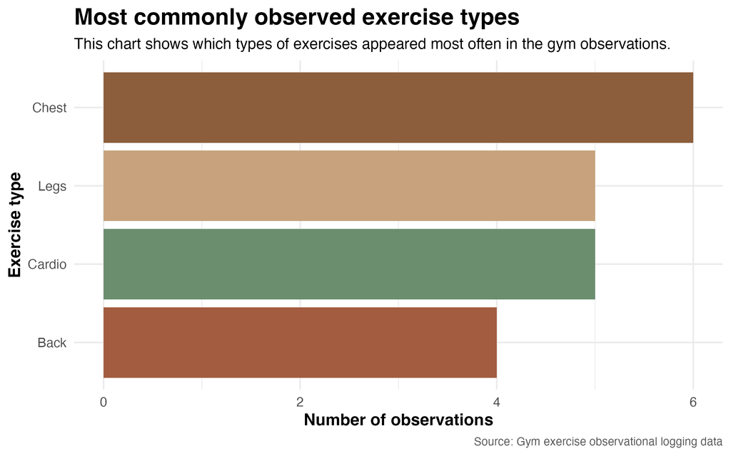

A horizontal bar chart showing the number of observations for each exercise type.

Chest exercises were the most common in my observations, with 6 observations. Legs and cardio were both observed 5 times, while back exercises were observed 4 times. This gives a basic picture of what people were mainly doing in the gym during the observation period.

## How long did different exercise types usually last?

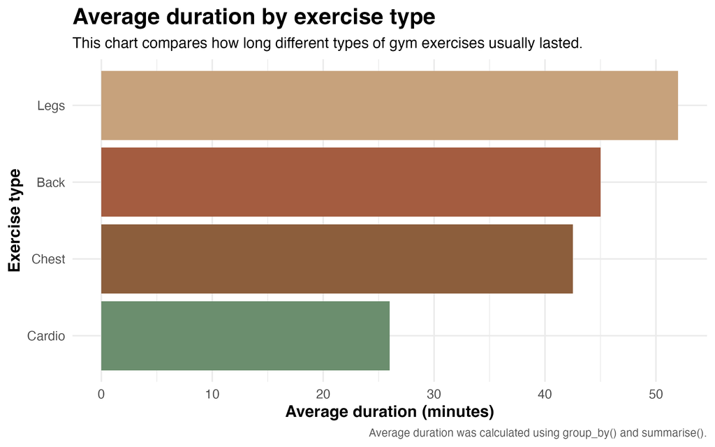

A horizontal bar chart showing the average duration in minutes for each exercise type.

Leg exercises had the longest average duration, at about 52 minutes. Back and chest exercises also had longer average durations than cardio. Cardio had the shortest average duration in this data, at about 26 minutes. This suggests that the cardio activities I observed were usually shorter sessions compared with strength training.

## How did crowdedness change by time of day?

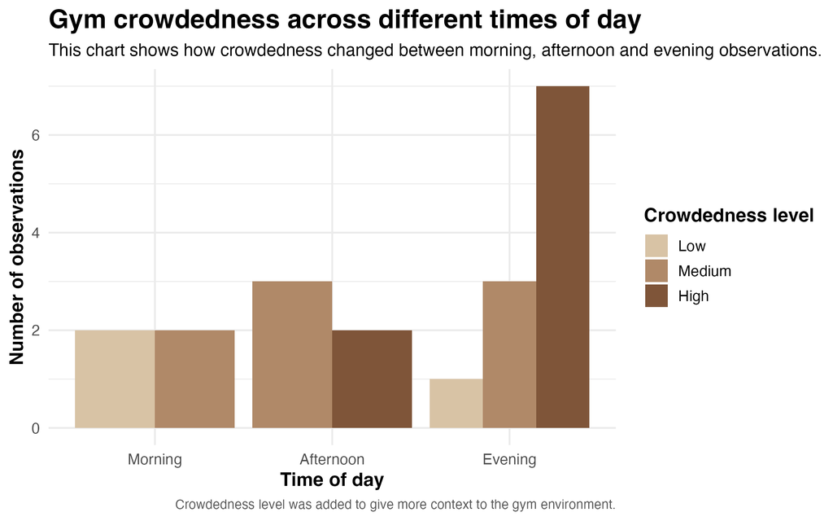

A grouped bar chart showing low, medium and high crowdedness levels across morning, afternoon and evening observations.

The evening observations were more likely to be recorded as highly crowded. Morning observations were less crowded overall, while afternoon observations were mostly medium. This pattern makes sense because many people may go to the gym later in the day after class, work or other daily activities.

## Did average exercise duration change over time?

[figure not shown]

A line chart showing average exercise duration across observation dates.

The average duration changed across the observation dates, but the pattern was not completely steady. Some days had shorter average sessions, while other days were closer to 45 minutes. This graph was useful because it used the timestamp variable instead of only comparing categories. It helped show how the observations changed across time.